# Salary Predictions Based upon Job Descriptions

# Part 1 - DEFINE

## ---- 1 Define the problem ----

The main object of this assignment is to examine a set of job postings with salaries and then predict salaries for a new set of job postings. The model will decide the remunerations for present as well as future employees of any organization.

With the help of Machine Learning, salaries will be forecasted depending upon years of experience, job type, college degree, college major, industry, and miles from a metropolis.

The raw data comprises training and test dataset in which training set has aforementioned attribues with the corresponding salaries while test dataset does not have salary information and would act as a real-world dataset.

The features of the datasets:

> - **Years Experience:** How many years of experience any person has.
> - **Job Type:** The position held (CEO, CFO, CTO, Vice President, Manager, Senior, Junior, Janitor).
> - **Degree:** Doctoral, Masters, Bachelors, High School, or None.
> - **Major:** Biology, Business, Chemistry, Computer Science, Engineering, Literature, Math, Physics, or None.
> - **Industry:** Auto, Education, Finance, Health, Oil, Service, or Web.
> - **Miles From Metropolis:** How many miles of commuting.

```python
'''This script loads, explores, and visualizes the datasets of salary prediction'''

__author__ = "Maulik Vyas"
__email__ = "vyasm433@gmail.com"
```

# Part 2 - DISCOVER

## ---- 2 Load the data ----

```python
#import your libraries
import pandas as pd
import numpy as np
from sklearn import metrics
import sklearn as sk
import matplotlib.pyplot as plt
import seaborn as sns
import warnings
warnings.filterwarnings("default")
%matplotlib inline

from sklearn.model_selection import train_test_split
from sklearn.model_selection import cross_val_score
from sklearn.ensemble import GradientBoostingRegressor
from sklearn.metrics import mean_squared_error
from sklearn.linear_model import LinearRegression
from sklearn.linear_model import Ridge
from sklearn.preprocessing import PolynomialFeatures
from sklearn.preprocessing import StandardScaler
from sklearn.pipeline import Pipeline
from sklearn.externals import joblib
```

```python
#load the raw data into a Pandas dataframe
train_feat = pd.read_csv(r"C:\\Users\\mauli\\OneDrive\\Documents\\GitHub\\salarypredictionportfolio\\data\\train_features.csv")
train_sal = pd.read_csv(r"C:\\Users\\mauli\\OneDrive\\Documents\\GitHub\\salarypredictionportfolio\\data\\train_salaries.csv")
test_feat = pd.read_csv(r"C:\\Users\\mauli\\OneDrive\\Documents\\GitHub\\salarypredictionportfolio\\data\\test_features.csv")
```

### Examine the data

```python
train_feat.head()
```

|  | jobId | companyId | jobType | degree | major | industry | yearsExperience | milesFromMetropolis |
| --- | --- | --- | --- | --- | --- | --- | --- | --- |
| 0 | JOB1362684407687 | COMP37 | CFO | MASTERS | MATH | HEALTH | 10 | 83 |
| 1 | JOB1362684407688 | COMP19 | CEO | HIGH_SCHOOL | NONE | WEB | 3 | 73 |
| 2 | JOB1362684407689 | COMP52 | VICE_PRESIDENT | DOCTORAL | PHYSICS | HEALTH | 10 | 38 |
| 3 | JOB1362684407690 | COMP38 | MANAGER | DOCTORAL | CHEMISTRY | AUTO | 8 | 17 |
| 4 | JOB1362684407691 | COMP7 | VICE_PRESIDENT | BACHELORS | PHYSICS | FINANCE | 8 | 16 |

```python
train_sal.head()
```

|  | jobId | salary |
| --- | --- | --- |
| 0 | JOB1362684407687 | 130 |
| 1 | JOB1362684407688 | 101 |
| 2 | JOB1362684407689 | 137 |
| 3 | JOB1362684407690 | 142 |
| 4 | JOB1362684407691 | 163 |

```python
test_feat.head()
```

|  | jobId | companyId | jobType | degree | major | industry | yearsExperience | milesFromMetropolis |
| --- | --- | --- | --- | --- | --- | --- | --- | --- |
| 0 | JOB1362685407687 | COMP33 | MANAGER | HIGH_SCHOOL | NONE | HEALTH | 22 | 73 |
| 1 | JOB1362685407688 | COMP13 | JUNIOR | NONE | NONE | AUTO | 20 | 47 |
| 2 | JOB1362685407689 | COMP10 | CTO | MASTERS | BIOLOGY | HEALTH | 17 | 9 |
| 3 | JOB1362685407690 | COMP21 | MANAGER | HIGH_SCHOOL | NONE | OIL | 14 | 96 |
| 4 | JOB1362685407691 | COMP36 | JUNIOR | DOCTORAL | BIOLOGY | OIL | 10 | 44 |

### Use .info() to check the length and datatypes

```python
train_feat.info()
```

```
<class 'pandas.core.frame.DataFrame'>
RangeIndex: 1000000 entries, 0 to 999999
Data columns (total 8 columns):
jobId                  1000000 non-null object
companyId              1000000 non-null object
jobType                1000000 non-null object
degree                 1000000 non-null object
major                  1000000 non-null object
industry               1000000 non-null object
yearsExperience        1000000 non-null int64
milesFromMetropolis    1000000 non-null int64
dtypes: int64(2), object(6)
memory usage: 61.0+ MB
```

```python
train_sal.info()
```

```
<class 'pandas.core.frame.DataFrame'>
RangeIndex: 1000000 entries, 0 to 999999
Data columns (total 2 columns):
jobId     1000000 non-null object
salary    1000000 non-null int64
dtypes: int64(1), object(1)
memory usage: 15.3+ MB
```

```python
test_feat.info()
```

```
<class 'pandas.core.frame.DataFrame'>
RangeIndex: 1000000 entries, 0 to 999999
Data columns (total 8 columns):
jobId                  1000000 non-null object
companyId              1000000 non-null object
jobType                1000000 non-null object
degree                 1000000 non-null object
major                  1000000 non-null object
industry               1000000 non-null object
yearsExperience        1000000 non-null int64
milesFromMetropolis    1000000 non-null int64
dtypes: int64(2), object(6)
memory usage: 61.0+ MB
```

## ---- 3 Clean the data ----

### Check for any duplicates

```python
train_feat.duplicated().sum()
```

```
0
```

```python
train_sal.duplicated().sum()
```

```
0
```

```python
test_feat.duplicated().sum()
```

```
0
```

### Identify numerical and categorical features

```python
train_feat.columns
```

```
Index(['jobId', 'companyId', 'jobType', 'degree', 'major', 'industry',
       'yearsExperience', 'milesFromMetropolis'],
      dtype='object')
```

```python
numeric_cols = ["yearsExperience", "milesFromMetropolis"]
```

```python
categoric_cols = ["jobId", "companyId", "jobType", "degree", "major", "industry"]
```

### Summarize numeric and categorical variables

```python
train_feat.describe(include=[np.number])
```

|  | yearsExperience | milesFromMetropolis |
| --- | --- | --- |
| count | 1000000.000000 | 1000000.000000 |
| mean | 11.992386 | 49.529260 |
| std | 7.212391 | 28.877733 |
| min | 0.000000 | 0.000000 |
| 25% | 6.000000 | 25.000000 |
| 50% | 12.000000 | 50.000000 |
| 75% | 18.000000 | 75.000000 |
| max | 24.000000 | 99.000000 |

```python
train_feat.describe(include=['O'])
```

|  | jobId | companyId | jobType | degree | major | industry |
| --- | --- | --- | --- | --- | --- | --- |
| count | 1000000 | 1000000 | 1000000 | 1000000 | 1000000 | 1000000 |
| unique | 1000000 | 63 | 8 | 5 | 9 | 7 |
| top | JOB1362684977477 | COMP39 | SENIOR | HIGH_SCHOOL | NONE | WEB |
| freq | 1 | 16193 | 125886 | 236976 | 532355 | 143206 |

### Merge attributes and outcome in one dataframe

```python
#Merge the features and salaries on jobId
train_data = pd.merge(train_feat, train_sal, on ='jobId')
train_data.head()
```

|  | jobId | companyId | jobType | degree | major | industry | yearsExperience | milesFromMetropolis | salary |
| --- | --- | --- | --- | --- | --- | --- | --- | --- | --- |
| 0 | JOB1362684407687 | COMP37 | CFO | MASTERS | MATH | HEALTH | 10 | 83 | 130 |
| 1 | JOB1362684407688 | COMP19 | CEO | HIGH_SCHOOL | NONE | WEB | 3 | 73 | 101 |
| 2 | JOB1362684407689 | COMP52 | VICE_PRESIDENT | DOCTORAL | PHYSICS | HEALTH | 10 | 38 | 137 |
| 3 | JOB1362684407690 | COMP38 | MANAGER | DOCTORAL | CHEMISTRY | AUTO | 8 | 17 | 142 |
| 4 | JOB1362684407691 | COMP7 | VICE_PRESIDENT | BACHELORS | PHYSICS | FINANCE | 8 | 16 | 163 |

### Delete original dataframe

```python
#Delete original file to save memory
del train_feat
del train_sal
```

```python
#Check length and datatypes of new dataframe
train_data.info()
```

```
<class 'pandas.core.frame.DataFrame'>
Int64Index: 1000000 entries, 0 to 999999
Data columns (total 9 columns):
jobId                  1000000 non-null object
companyId              1000000 non-null object
jobType                1000000 non-null object
degree                 1000000 non-null object
major                  1000000 non-null object
industry               1000000 non-null object
yearsExperience        1000000 non-null int64
milesFromMetropolis    1000000 non-null int64
salary                 1000000 non-null int64
dtypes: int64(3), object(6)
memory usage: 76.3+ MB
```

### Check for missing data

```python
missing_data = train_data.isnull().sum()
missing_data
```

```
jobId                  0
companyId              0
jobType                0
degree                 0
major                  0
industry               0
yearsExperience        0
milesFromMetropolis    0
salary                 0
dtype: int64
```

```python
#Convert the object into categorical data

train_data["jobId"]=pd.Categorical(train_data["jobId"])
train_data["companyId"]=pd.Categorical(train_data["companyId"])
train_data["jobType"]=pd.Categorical(train_data["jobType"])
train_data["degree"]=pd.Categorical(train_data["degree"])
train_data["major"]=pd.Categorical(train_data["major"])
train_data["industry"]=pd.Categorical(train_data["industry"])
train_data.dtypes
```

```
jobId                  category
companyId              category
jobType                category
degree                 category
major                  category
industry               category
yearsExperience           int64
milesFromMetropolis       int64
salary                    int64
dtype: object
```

## ---- 4 Explore the data (EDA) ----

### Summarize the features and target variables

```python
#Descriptive statistics of train data
train_data.describe()
```

|  | yearsExperience | milesFromMetropolis | salary |
| --- | --- | --- | --- |
| count | 1000000.000000 | 1000000.000000 | 1000000.000000 |
| mean | 11.992386 | 49.529260 | 116.061818 |
| std | 7.212391 | 28.877733 | 38.717936 |
| min | 0.000000 | 0.000000 | 0.000000 |
| 25% | 6.000000 | 25.000000 | 88.000000 |
| 50% | 12.000000 | 50.000000 | 114.000000 |
| 75% | 18.000000 | 75.000000 | 141.000000 |
| max | 24.000000 | 99.000000 | 301.000000 |

```python
#Unique value in the data
train_data.nunique()
```

```
jobId                  1000000
companyId                   63
jobType                      8
degree                       5
major                        9
industry                     7
yearsExperience             25
milesFromMetropolis        100
salary                     280
dtype: int64
```

```python
stats = train_data.salary.describe()
print(stats)
IQR = stats["75%"] - stats["25%"]
upper = stats["75%"] + 1.5 * IQR
lower = stats["25%"] - 1.5 * IQR
print("The upper and lower bounds for suspected outliers are {} and {}".format(upper,lower))
```

```
count    1000000.000000
mean         116.061818
std           38.717936
min            0.000000
25%           88.000000
50%          114.000000
75%          141.000000
max          301.000000
Name: salary, dtype: float64
The upper and lower bounds for suspected outliers are 220.5 and 8.5
```

### Examine potential outliers

```python
#Check potential outliers below lower bounds
train_data[train_data.salary < 8.5]
```

|  | jobId | companyId | jobType | degree | major | industry | yearsExperience | milesFromMetropolis | salary |
| --- | --- | --- | --- | --- | --- | --- | --- | --- | --- |
| 30559 | JOB1362684438246 | COMP44 | JUNIOR | DOCTORAL | MATH | AUTO | 11 | 7 | 0 |
| 495984 | JOB1362684903671 | COMP34 | JUNIOR | NONE | NONE | OIL | 1 | 25 | 0 |
| 652076 | JOB1362685059763 | COMP25 | CTO | HIGH_SCHOOL | NONE | AUTO | 6 | 60 | 0 |
| 816129 | JOB1362685223816 | COMP42 | MANAGER | DOCTORAL | ENGINEERING | FINANCE | 18 | 6 | 0 |
| 828156 | JOB1362685235843 | COMP40 | VICE_PRESIDENT | MASTERS | ENGINEERING | WEB | 3 | 29 | 0 |

From the entries in jobType and degree, it could be believed that these positions are not volunteery and the salary data is missing or corrupt, so we should remove this data from our dataframe.

```python
#Check potential outliers above upper bounds
train_data.loc[train_data.salary > 222.5, "jobType"].value_counts()
```

```
CEO               2893
CFO               1308
CTO               1298
VICE_PRESIDENT     520
MANAGER            188
SENIOR              50
JUNIOR              16
JANITOR              0
Name: jobType, dtype: int64
```

```python
#Check potential outliers above upper bounds
train_data[(train_data.salary > 222.5) & (train_data.jobType == "JUNIOR")]
```

|  | jobId | companyId | jobType | degree | major | industry | yearsExperience | milesFromMetropolis | salary |
| --- | --- | --- | --- | --- | --- | --- | --- | --- | --- |
| 1222 | JOB1362684408909 | COMP40 | JUNIOR | MASTERS | COMPSCI | OIL | 24 | 5 | 225 |
| 27710 | JOB1362684435397 | COMP21 | JUNIOR | DOCTORAL | ENGINEERING | OIL | 24 | 3 | 246 |
| 31355 | JOB1362684439042 | COMP45 | JUNIOR | DOCTORAL | COMPSCI | FINANCE | 24 | 0 | 225 |
| 100042 | JOB1362684507729 | COMP17 | JUNIOR | DOCTORAL | BUSINESS | FINANCE | 23 | 8 | 248 |
| 160333 | JOB1362684568020 | COMP18 | JUNIOR | DOCTORAL | BUSINESS | FINANCE | 22 | 3 | 223 |
| 303778 | JOB1362684711465 | COMP51 | JUNIOR | MASTERS | ENGINEERING | WEB | 24 | 2 | 226 |
| 348354 | JOB1362684756041 | COMP56 | JUNIOR | DOCTORAL | ENGINEERING | OIL | 23 | 25 | 226 |
| 500739 | JOB1362684908426 | COMP40 | JUNIOR | DOCTORAL | ENGINEERING | OIL | 21 | 0 | 227 |
| 627534 | JOB1362685035221 | COMP5 | JUNIOR | DOCTORAL | ENGINEERING | OIL | 24 | 29 | 230 |
| 645555 | JOB1362685053242 | COMP36 | JUNIOR | DOCTORAL | BUSINESS | FINANCE | 24 | 1 | 225 |
| 685775 | JOB1362685093462 | COMP38 | JUNIOR | BACHELORS | ENGINEERING | OIL | 24 | 13 | 225 |
| 743326 | JOB1362685151013 | COMP14 | JUNIOR | DOCTORAL | BUSINESS | FINANCE | 19 | 0 | 236 |
| 787674 | JOB1362685195361 | COMP43 | JUNIOR | DOCTORAL | BUSINESS | FINANCE | 18 | 15 | 232 |
| 796956 | JOB1362685204643 | COMP30 | JUNIOR | MASTERS | BUSINESS | OIL | 24 | 2 | 228 |
| 855219 | JOB1362685262906 | COMP13 | JUNIOR | MASTERS | ENGINEERING | OIL | 22 | 26 | 225 |
| 954368 | JOB1362685362055 | COMP11 | JUNIOR | DOCTORAL | BUSINESS | OIL | 24 | 26 | 223 |

Even though the job type and salaries do not match together, the degree, major and the amount of experience clearly justify the salary, so we should keep them in our dataframe and do not remvoe them.

```python
#Remove the missing data
train_data = train_data[train_data.salary > 8.5]
```

### Look for correlation

```python
#Find the correlation matrix
train_data.corr()
```

|  | yearsExperience | milesFromMetropolis | salary |
| --- | --- | --- | --- |
| yearsExperience | 1.000000 | 0.000672 | 0.375013 |
| milesFromMetropolis | 0.000672 | 1.000000 | -0.297686 |
| salary | 0.375013 | -0.297686 | 1.000000 |

```python
train_data.skew()
```

```
yearsExperience        0.001671
milesFromMetropolis   -0.001144
salary                 0.346527
dtype: float64
```

```python
train_data.kurt()
```

```
yearsExperience       -1.205126
milesFromMetropolis   -1.199018
salary                -0.025751
dtype: float64
```

### Visualize target variable (salary)

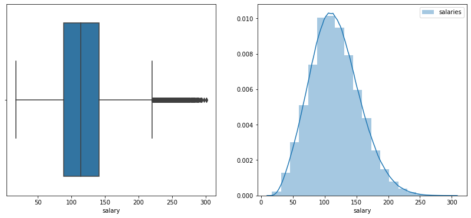

```python
plt.figure(figsize = (14, 6))
plt.subplot(1,2,1)
sns.boxplot(train_data.salary)
plt.subplot(1,2,2)
sns.distplot(train_data.salary, bins=20, label="salaries")
plt.legend()
plt.show()
```

```python
%pylab inline
pylab.rcParams['figure.figsize'] = (14, 6)
```

### Visualize all features

```python
def plot_attribute(train_data, col):
    '''
    Make plot for every attribute
    left plot, the distribution of samples on the attribute
    right plot, the dependance of salary on the attribute
    '''
    plt.figure(figsize = (14, 6))
    plt.subplot(1, 2, 1)
    if train_data[col].dtype == 'int64':
        train_data[col].value_counts().sort_index().plot()
    else:
        #change the categorical variable to category type and order their level by the mean salary in each category
        mean = train_data.groupby(col)['salary'].mean()
        train_data[col] = train_data[col].astype('category')
        levels = mean.sort_values().index.tolist()
        train_data[col].cat.reorder_categories(levels, inplace=True)
        train_data[col].value_counts().plot()

    plt.xticks(rotation=45)
    plt.xlabel(col)
    plt.ylabel('Counts')
    plt.subplot(1, 2, 2)

    if train_data[col].dtype == 'int64' or col == 'companyId':
        #plot the mean salary for each category and fill between the (mean - std, mean + std)
        mean = train_data.groupby(col)['salary'].mean()
        std = train_data.groupby(col)['salary'].std()
        mean.plot()
        plt.fill_between(range(len(std.index)), mean.values-std.values, mean.values + std.values, \
                         alpha = 0.2)
    else:
        sns.boxplot(x = col, y = 'salary', data=train_data)

    plt.xticks(rotation=45)
    plt.ylabel('Salaries')
    plt.show()
```

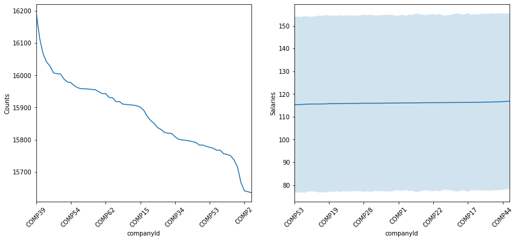

```python
plot_attribute(train_data, 'companyId')
```

Here, companyId does not provide any pattern, so it should be dropped out.

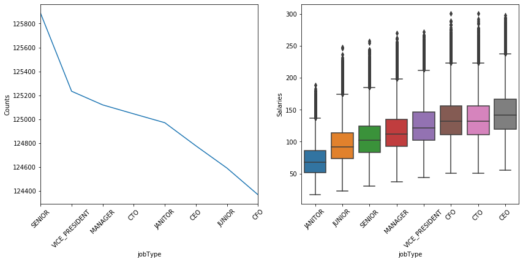

```python
plot_attribute(train_data, 'jobType')
```

Janitors get the lowest salary, while as the level of seniority goes up, the salary increases and the CEO gets the highest salary.

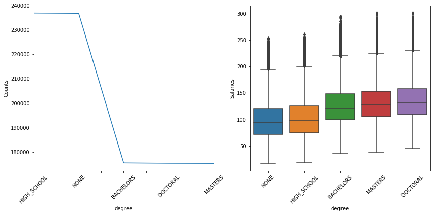

```python
plot_attribute(train_data, 'degree')
```

People without degree or with a high school obtain the lower salaries in comparison with people who have bachelors, masters or doctoral.

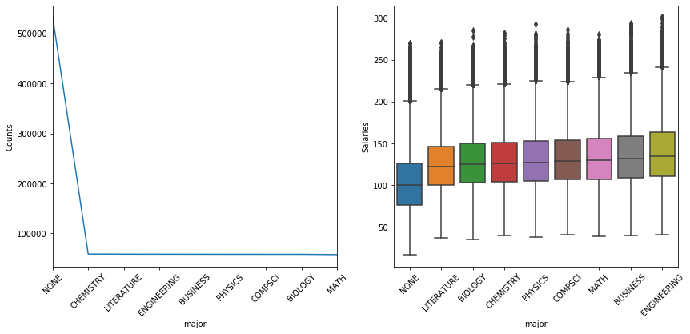

```python
plot_attribute(train_data, 'major')
```

Employees who are major in any subject get nearly same salary. However, those without any major obtain 20% lower wages than their peers.

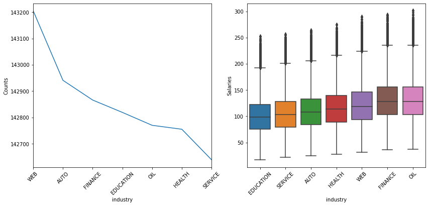

```python
plot_attribute(train_data, 'industry')
```

The highest wages are paid in Oil and Finance industries, whereas employees in Education sector get the lowest remuneration.

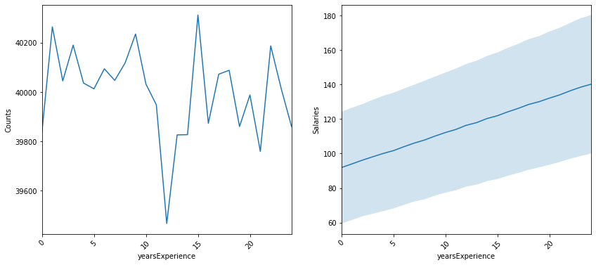

```python
plot_attribute(train_data, 'yearsExperience')
```

The graph clearly shows that as experience increases, the amount of salary goes up.

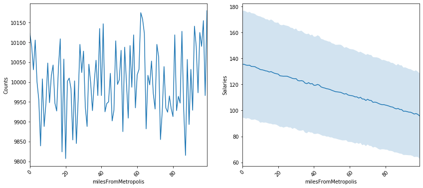

```python
plot_attribute(train_data, 'milesFromMetropolis')
```

Here, the salary and miles from metropolis has the inverse relationship. As you live far from metro cities, your salary goes down.

### Remove jobId and companyId

```python
#As they don't give any insight
train_data.drop('jobId', axis=1, inplace=True)
train_data.drop('companyId', axis=1, inplace=True)

train_data.head()
```

|  | jobType | degree | major | industry | yearsExperience | milesFromMetropolis | salary |
| --- | --- | --- | --- | --- | --- | --- | --- |
| 0 | CFO | MASTERS | MATH | HEALTH | 10 | 83 | 130 |
| 1 | CEO | HIGH_SCHOOL | NONE | WEB | 3 | 73 | 101 |
| 2 | VICE_PRESIDENT | DOCTORAL | PHYSICS | HEALTH | 10 | 38 | 137 |
| 3 | MANAGER | DOCTORAL | CHEMISTRY | AUTO | 8 | 17 | 142 |
| 4 | VICE_PRESIDENT | BACHELORS | PHYSICS | FINANCE | 8 | 16 | 163 |

### One hot encoding

```python
#One hot encoding categorical data in train set
train_data = pd.get_dummies(train_data)
train_data.head()
```

|  | yearsExperience | milesFromMetropolis | salary | jobType_JANITOR | jobType_JUNIOR | jobType_SENIOR | jobType_MANAGER | jobType_VICE_PRESIDENT | jobType_CFO | jobType_CTO | ... | major_MATH | major_BUSINESS | major_ENGINEERING | industry_EDUCATION | industry_SERVICE | industry_AUTO | industry_HEALTH | industry_WEB | industry_FINANCE | industry_OIL |
| --- | --- | --- | --- | --- | --- | --- | --- | --- | --- | --- | --- | --- | --- | --- | --- | --- | --- | --- | --- | --- | --- |
| 0 | 10 | 83 | 130 | 0 | 0 | 0 | 0 | 0 | 1 | 0 | ... | 1 | 0 | 0 | 0 | 0 | 0 | 1 | 0 | 0 | 0 |
| 1 | 3 | 73 | 101 | 0 | 0 | 0 | 0 | 0 | 0 | 0 | ... | 0 | 0 | 0 | 0 | 0 | 0 | 0 | 1 | 0 | 0 |
| 2 | 10 | 38 | 137 | 0 | 0 | 0 | 0 | 1 | 0 | 0 | ... | 0 | 0 | 0 | 0 | 0 | 0 | 1 | 0 | 0 | 0 |
| 3 | 8 | 17 | 142 | 0 | 0 | 0 | 1 | 0 | 0 | 0 | ... | 0 | 0 | 0 | 0 | 0 | 1 | 0 | 0 | 0 | 0 |
| 4 | 8 | 16 | 163 | 0 | 0 | 0 | 0 | 1 | 0 | 0 | ... | 0 | 0 | 0 | 0 | 0 | 0 | 0 | 0 | 1 | 0 |

5 rows × 32 columns

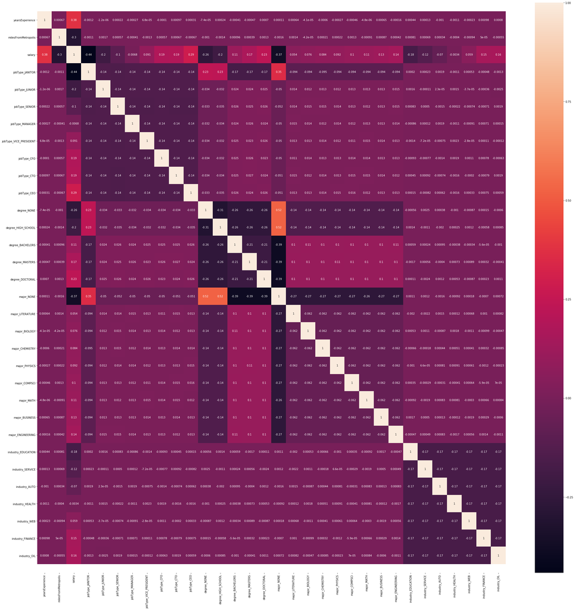

```python
#Plot heatmap of all data with correlation coefficients visible
train_data_corr = train_data.corr()
plt.subplots(figsize=(40,40))
sns.heatmap(train_data_corr, cbar=True, annot=True, fmt=".2g")
b, t = plt.ylim()
b += 0.5
t -= 0.5
plt.ylim(b,t)
plt.show()
```

### Split data into train and test data set

```python
X = train_data[train_data.loc[ : , train_data.columns != 'salary'].columns]
y = train_data['salary']
X_train, X_test, y_train, y_test = train_test_split(X, y, test_size=0.2, random_state=1)
```

```python
X_train.head()
y_train.head()
```

```
583584     90
465089    164
686217     87
176613    126
249786    133
Name: salary, dtype: int64
```

```python
print('Inputs: \n', X_train.head())
print('Outputs: \n', y_train.head())
```

```
Inputs:
         yearsExperience  milesFromMetropolis  jobType_JANITOR  jobType_JUNIOR  \
583584               17                   75                0               0
465089               14                   88                0               0
686217               12                   65                0               1
176613                8                   68                0               0
249786                3                   13                0               0

        jobType_SENIOR  jobType_MANAGER  jobType_VICE_PRESIDENT  jobType_CFO  \
583584               0                0                       1            0
465089               0                0                       0            0
686217               0                0                       0            0
176613               1                0                       0            0
249786               0                0                       1            0

```

[output cut: 36 more lines]

# Part 3 - DEVELOP

## ---- 5 Create models ----

### Linear Regression

```python
#Create linear regression
lm = LinearRegression()
lm.fit(X_train, y_train)
lm
```

```
LinearRegression(copy_X=True, fit_intercept=True, n_jobs=None, normalize=False)
```

```python
print(lm.intercept_)
print(lm.coef_)
```

```
54205785293.2069
[ 2.01084636e+00 -3.99647595e-01 -3.73538662e+10 -3.73538661e+10
 -3.73538661e+10 -3.73538661e+10 -3.73538661e+10 -3.73538661e+10
 -3.73538661e+10 -3.73538661e+10 -8.10600215e+09 -8.10600214e+09
 -8.10600214e+09 -8.10600213e+09 -8.10600213e+09 -1.62536367e+09
 -1.62536367e+09 -1.62536367e+09 -1.62536367e+09 -1.62536366e+09
 -1.62536366e+09 -1.62536366e+09 -1.62536366e+09 -1.62536366e+09
 -7.12055327e+09 -7.12055326e+09 -7.12055326e+09 -7.12055325e+09
 -7.12055325e+09 -7.12055324e+09 -7.12055324e+09]
```

```python
#Converting the coefficient values to a dataframe
coeffcients = pd.DataFrame([X_train.columns,lm.coef_]).T
coeffcients = coeffcients.rename(columns={0: 'Attribute', 1: 'Coefficients'})
coeffcients
```

|  | Attribute | Coefficients |
| --- | --- | --- |
| 0 | yearsExperience | 2.01085 |
| 1 | milesFromMetropolis | -0.399648 |
| 2 | jobType_JANITOR | -3.73539e+10 |
| 3 | jobType_JUNIOR | -3.73539e+10 |
| 4 | jobType_SENIOR | -3.73539e+10 |
| 5 | jobType_MANAGER | -3.73539e+10 |
| 6 | jobType_VICE_PRESIDENT | -3.73539e+10 |
| 7 | jobType_CFO | -3.73539e+10 |
| 8 | jobType_CTO | -3.73539e+10 |
| 9 | jobType_CEO | -3.73539e+10 |
| 10 | degree_NONE | -8.106e+09 |
| 11 | degree_HIGH_SCHOOL | -8.106e+09 |
| 12 | degree_BACHELORS | -8.106e+09 |
| 13 | degree_MASTERS | -8.106e+09 |
| 14 | degree_DOCTORAL | -8.106e+09 |
| 15 | major_NONE | -1.62536e+09 |
| 16 | major_LITERATURE | -1.62536e+09 |
| 17 | major_BIOLOGY | -1.62536e+09 |
| 18 | major_CHEMISTRY | -1.62536e+09 |
| 19 | major_PHYSICS | -1.62536e+09 |
| 20 | major_COMPSCI | -1.62536e+09 |
| 21 | major_MATH | -1.62536e+09 |
| 22 | major_BUSINESS | -1.62536e+09 |
| 23 | major_ENGINEERING | -1.62536e+09 |
| 24 | industry_EDUCATION | -7.12055e+09 |
| 25 | industry_SERVICE | -7.12055e+09 |
| 26 | industry_AUTO | -7.12055e+09 |
| 27 | industry_HEALTH | -7.12055e+09 |
| 28 | industry_WEB | -7.12055e+09 |
| 29 | industry_FINANCE | -7.12055e+09 |
| 30 | industry_OIL | -7.12055e+09 |

```python
yhat = lm.predict(X_train)
print("The output of the first five predicted values are: ", yhat[0:5])
```

```
The output of the first five predicted values are:  [126.75416565 144.07197571  93.90700531 113.80144501 133.27671814]
```

```python
#Print MSE of training data
print("The mean squared error of ourr prediction model is:", mean_squared_error(y_train,yhat))
```

```
The mean squared error of ourr prediction model is: 384.26948301144864
```

```python
#Print accuracy score using 5-fold cross validation
scores = cross_val_score(lm, X_train, y_train, cv=2)
print("5-Fold Cross Validation Accuracy (train_data):", (np.mean(scores)), (np.std(scores)))
```

```
5-Fold Cross Validation Accuracy (train_data): 0.7433113187468426 1.7554190956392546e-07
```

```python
#Linear regression in variable
yhat_test = lm.predict(X_test)
yhat_test[:5]
```

```
array([157.7997818 ,  62.36647797, 108.70929718, 112.59149933,
        92.51925659])
```

```python
# Print MSE of testing data
print("The mean squared error of our test set predicitons is:", mean_squared_error(y_test, yhat_test))
```

```
The mean squared error of our test set predicitons is: 384.82986860214265
```

```python
# Print accuracy score using 5-fold cross validation
scores = cross_val_score(lm, X_test, y_test, cv=2, n_jobs = 2)
print("5-Fold Cross Validation Accuracy (test data):", (np.mean(scores)), (np.std(scores)))
```

```
5-Fold Cross Validation Accuracy (test data): 0.744352523677869 0.0020232631833393966
```

While comparing the training and testing data, Accuracy score, and MSE are not incredibly different. The objective here is to lower MSE to 360 or less.

### Second order Polynomial Linear Regression

```python
#Fit and transform the variables using 2nd order polynomial
pr = PolynomialFeatures(2)
X_train_pr = pr.fit_transform(X_train)
X_test_pr = pr.fit_transform(X_test)
pr
```

```
PolynomialFeatures(degree=2, include_bias=True, interaction_only=False,
                   order='C')
```

```python
poly = LinearRegression()
poly.fit(X_train_pr, y_train)
```

```
LinearRegression(copy_X=True, fit_intercept=True, n_jobs=None, normalize=False)
```

```python
yhat_prTrain = poly.predict(X_train_pr)
yhat_prTrain[0:5]
```

```
array([122.82506192, 154.63508236,  93.933056  , 108.48295224,
       124.47292912])
```

```python
print("Predicted Values:", yhat_prTrain[0:5])
print("True Values:", y_test[0:5].values)
```

```
Predicted Values: [122.82506192 154.63508236  93.933056   108.48295224 124.47292912]
True Values: [186  67  82 104 106]
```

```python
yhat_prTest = poly.predict(X_test_pr)
yhat_prTest[0:5]
```

```
array([159.42986691,  60.13763058,  96.80137265,  99.58772027,
        93.36851132])
```

```python
print("Predicted Values:", yhat_prTest[0:5])
print("True Values:", y_test[0:5].values)
```

```
Predicted Values: [159.42986691  60.13763058  96.80137265  99.58772027  93.36851132]
True Values: [186  67  82 104 106]
```

```python
print("R-Squared of training data:", poly.score(X_train_pr,y_train))
print("R-Squared of testing data:", poly.score(X_test_pr,y_test))
```

```
R-Squared of training data: 0.7638918399282681
R-Squared of testing data: 0.7645109723462395
```

```python
print("MSE of training data:", mean_squared_error(y_train,yhat_prTrain))
print("MSE of testing data:", mean_squared_error(y_test,yhat_prTest))
```

```
MSE of training data: 353.515214270834
MSE of testing data: 354.6541416753932
```

### Gradient Boosting Regressor

```python
from sklearn.ensemble import GradientBoostingRegressor
gbm = GradientBoostingRegressor(n_estimators=150, max_depth=5, loss='ls', verbose=0)
gbm.fit(X_train, y_train)
gbm
```

```
GradientBoostingRegressor(alpha=0.9, criterion='friedman_mse', init=None,
                          learning_rate=0.1, loss='ls', max_depth=5,
                          max_features=None, max_leaf_nodes=None,
                          min_impurity_decrease=0.0, min_impurity_split=None,
                          min_samples_leaf=1, min_samples_split=2,
                          min_weight_fraction_leaf=0.0, n_estimators=150,
                          n_iter_no_change=None, presort='auto',
                          random_state=None, subsample=1.0, tol=0.0001,
                          validation_fraction=0.1, verbose=0, warm_start=False)
```

```python
yhat_gbm = gbm.predict(X_train)
print("The output of the first five predicted values are: ", yhat_gbm[0:5])
```

```
The output of the first five predicted values are:  [122.59729809 155.01364     95.6064968  109.9001815  125.02747665]
```

```python
#Print MSE of training data
print("The mean squared error of the prediction model is:", mean_squared_error(y_train,yhat_gbm))
```

```
The mean squared error of the prediction model is: 354.54403362179625
```

```python
#Print accuracy score using 5-fold cross validation
scores = cross_val_score(gbm, X_train, y_train, cv=2)
print("5-Fold Cross Validation Accuracy (train_data):", (np.mean(scores)), (np.std(scores)))
```

```
5-Fold Cross Validation Accuracy (train_data): 0.7614106477257145 1.6849719308709155e-06
```

```python
#Linear regression in variable
yhat_test_gbm = gbm.predict(X_test)
yhat_test_gbm[:5]
```

```
array([155.91292688,  62.20491499,  96.88228414, 101.17543451,
        97.2718429 ])
```

```python
# Print MSE of testing data
print("The mean squared error of our test set predicitons is:", mean_squared_error(y_test, yhat_test_gbm))
```

```
The mean squared error of our test set predicitons is: 357.65775643335604
```

```python
# Print accuracy score using 5-fold cross validation
scores = cross_val_score(gbm, X_test, y_test, cv=2, n_jobs = 2)
print("5-Fold Cross Validation Accuracy (test data):", (np.mean(scores)), (np.std(scores)))
```

```
5-Fold Cross Validation Accuracy (test data): 0.76031528178174 0.0016106114317159803
```

### Ridge Regression

```python
RidgeModel = Ridge(alpha=0.0001)
```

```python
RidgeModel.fit(X_train_pr,y_train)
```

```
Ridge(alpha=0.0001, copy_X=True, fit_intercept=True, max_iter=None,
      normalize=False, random_state=None, solver='auto', tol=0.001)
```

```python
yhat_ridge_train = RidgeModel.predict(X_train_pr)
yhat_ridge_test = RidgeModel.predict(X_test_pr)
```

```python
print('Predicted:', yhat_ridge_train[0:4])
print('Actual :', y_train[0:4].values)
```

```
Predicted: [122.80519304 154.601786    93.93271715 108.47095231]
Actual : [ 90 164  87 126]
```

```python
print('Predicted:', yhat_ridge_test[0:4])
print('Actual :', y_test[0:4].values)
```

```
Predicted: [159.45554396  60.1115973   96.81862943  99.59683356]
Actual : [186  67  82 104]
```

```python
print("R Squared of training data:", RidgeModel.score(X_train_pr, y_train))
print("R Squared of testing data:", RidgeModel.score(X_test_pr, y_test))
```

```
R Squared of training data: 0.7638922264219945
R Squared of testing data: 0.7645107916745375
```

```python
print("MSE of training data:", mean_squared_error(yhat_ridge_train, y_train))
print("MSE of testing data:", mean_squared_error(yhat_ridge_test, y_test))
```

```
MSE of training data: 353.5146355893838
MSE of testing data: 354.65441377285794
```

Here, we get lower MSE from 2nd order polynomial and Ridge regression, so we select Ridge Regression for the final step: Deploy

# Part 4 - DEPLOY

### ---- 6 Automate Pipeline ----

```python
# Create pipeline for polynomial regression
Input = [('polynomial', PolynomialFeatures(include_bias=False)), ('model', Ridge())]
pipe = Pipeline(Input)
pipe
```

```
Pipeline(memory=None,
         steps=[('polynomial',
                 PolynomialFeatures(degree=2, include_bias=False,
                                    interaction_only=False, order='C')),
                ('model',
                 Ridge(alpha=1.0, copy_X=True, fit_intercept=True,
                       max_iter=None, normalize=False, random_state=None,
                       solver='auto', tol=0.001))],
         verbose=False)
```

```python
RRModel =  pipe.fit(X, y)
```

```python
ypipe = pipe.predict(X)
ypipe[0:5]
```

```
array([127.12445325, 116.46016062, 135.15487426, 120.91011595,
       142.63347255])
```

```python
# Now model can be saved to use anytime
filename = 'final_salary_model.csv'
joblib.dump(RRModel, filename)
```

```
['final_salary_model.csv']
```

```python
# Load model
loaded_model = joblib.load(filename)
```

```python
# See result of test data with known salaries
result = loaded_model.score(X_test, y_test)
print(result)
```

```
0.764657607911462
```

### ---- 7 Prepare test data ----

```python
# Load new data into dataframe
test_feat = pd.DataFrame(test_feat)

# Convert features to same types used in model
test_feat['jobId']=pd.Categorical(test_feat['jobId'])
test_feat['companyId']=pd.Categorical(test_feat['companyId'])
test_feat['jobType']=pd.Categorical(test_feat['jobType'])
test_feat['degree']=pd.Categorical(test_feat['degree'])
test_feat['major']=pd.Categorical(test_feat['major'])
test_feat['industry']=pd.Categorical(test_feat['industry'])

# Drop features not relevant to salary prediction
test_feat.drop('jobId', axis=1, inplace=True)
test_feat.drop('companyId', axis=1, inplace=True)

# One-hot encode categorical data
test_feat = pd.get_dummies(test_feat)

# View top 5 rows of data
test_feat.head(5)
```

|  | yearsExperience | milesFromMetropolis | jobType_CEO | jobType_CFO | jobType_CTO | jobType_JANITOR | jobType_JUNIOR | jobType_MANAGER | jobType_SENIOR | jobType_VICE_PRESIDENT | ... | major_MATH | major_NONE | major_PHYSICS | industry_AUTO | industry_EDUCATION | industry_FINANCE | industry_HEALTH | industry_OIL | industry_SERVICE | industry_WEB |
| --- | --- | --- | --- | --- | --- | --- | --- | --- | --- | --- | --- | --- | --- | --- | --- | --- | --- | --- | --- | --- | --- |
| 0 | 22 | 73 | 0 | 0 | 0 | 0 | 0 | 1 | 0 | 0 | ... | 0 | 1 | 0 | 0 | 0 | 0 | 1 | 0 | 0 | 0 |
| 1 | 20 | 47 | 0 | 0 | 0 | 0 | 1 | 0 | 0 | 0 | ... | 0 | 1 | 0 | 1 | 0 | 0 | 0 | 0 | 0 | 0 |
| 2 | 17 | 9 | 0 | 0 | 1 | 0 | 0 | 0 | 0 | 0 | ... | 0 | 0 | 0 | 0 | 0 | 0 | 1 | 0 | 0 | 0 |
| 3 | 14 | 96 | 0 | 0 | 0 | 0 | 0 | 1 | 0 | 0 | ... | 0 | 1 | 0 | 0 | 0 | 0 | 0 | 1 | 0 | 0 |
| 4 | 10 | 44 | 0 | 0 | 0 | 0 | 1 | 0 | 0 | 0 | ... | 0 | 0 | 0 | 0 | 0 | 0 | 0 | 1 | 0 | 0 |

5 rows × 31 columns

```python
# Predict salaries from new data
loaded_model.predict(test_feat)
```

```
array([142.98458905, 139.32970337, 135.79393743, ..., 102.38905362,
       122.91940555, 158.91103476])
```